# Section 3: Data Wrangling (Part 1)

MTH 365: Introduction to Data Science

September 11, 2020

## Recommended Reading

- *Modern Data Science with R* Ch. 4: Data Wrangling
- *Modern Data Science with R* Ch. 5: Tidy Data and Iteration
- Wickham, Hadley. (2014). “Tidy Data”. *Journal of Statistical Software* 59(10). Available on BlueLine.

```r
library(tidyverse)
```

## Data structure and semantics

- Most statistical datasets are tables made up of *rows* and *columns*

A dataset is a collection of *values*: these can be *numbers* (quantitative) or character *strings* (qualitative)

- Every value belongs to a variable and an observation

**Variable**:

**Observation**:

## Tidy data

“Tidy” data is a standard way of mapping the meaning of a dataset to its structure.

1. Each variable forms a column.
2. Each observation forms a row.
3. Each type of observational unit forms a table.

Any other arrangement of the data is called “messy”.

| person | treatment | result |
| --- | --- | --- |
| John Smith | a | - |
| Jane Doe | a | 16 |
| Mary Johnson | a | 3 |
| John Smith | b | 2 |
| Jane Doe | b | 11 |
| Mary Johnson | b | 1 |

Real datasets can, and often do, violate the three principles of tidy data in almost every way imaginable!

## Example: Gapminder

Gapminder is an independent Swedish foundation with no political, religious or economic affiliations. **Gapminder is a fact tank, not a think tank.** Gapminder fights devastating misconceptions about global development. Gapminder produces free teaching resources making the world understandable based on reliable statistics. Gapminder promotes a fact-based worldview everyone can understand. Gapminder collaborates with universities, UN, public agencies and non-governmental organizations.

## Loading the Gapminder data set

```r
library(dslabs)
library(tidyverse)
data(gapminder)
glimpse(gapminder)
```

```
## Rows: 10,545
## Columns: 9
## $ country          <fct> Albania, Algeria, Angola, Antigua and Barbuda, Arg...
## $ year             <int> 1960, 1960, 1960, 1960, 1960, 1960, 1960, 1960, 19...
## $ infant_mortality <dbl> 115.40, 148.20, 208.00, NA, 59.87, NA, NA, 20.30, ...
## $ life_expectancy  <dbl> 62.87, 47.50, 35.98, 62.97, 65.39, 66.86, 65.66, 7...
## $ fertility        <dbl> 6.19, 7.65, 7.32, 4.43, 3.11, 4.55, 4.82, 3.45, 2....
## $ population       <dbl> 1636054, 11124892, 5270844, 54681, 20619075, 18673...
## $ gdp              <dbl> NA, 13828152297, NA, NA, 108322326649, NA, NA, 966...
## $ continent        <fct> Europe, Africa, Africa, Americas, Americas, Asia, ...
## $ region           <fct> Southern Europe, Northern Africa, Middle Africa, C...
```

## Exploring the Gapminder data set

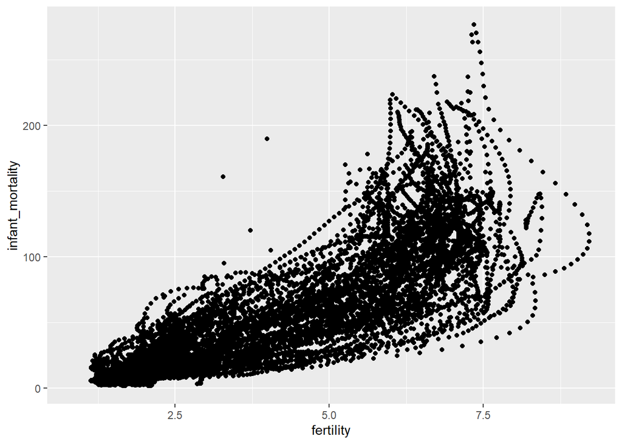

```r
ggplot(gapminder, aes(x=fertility, y=infant_mortality)) +
  geom_point()
```

[figure not shown]

```r
ggplot(gapminder, aes(x=fertility, y=infant_mortality)) +
  geom_point(aes(col=country))
```

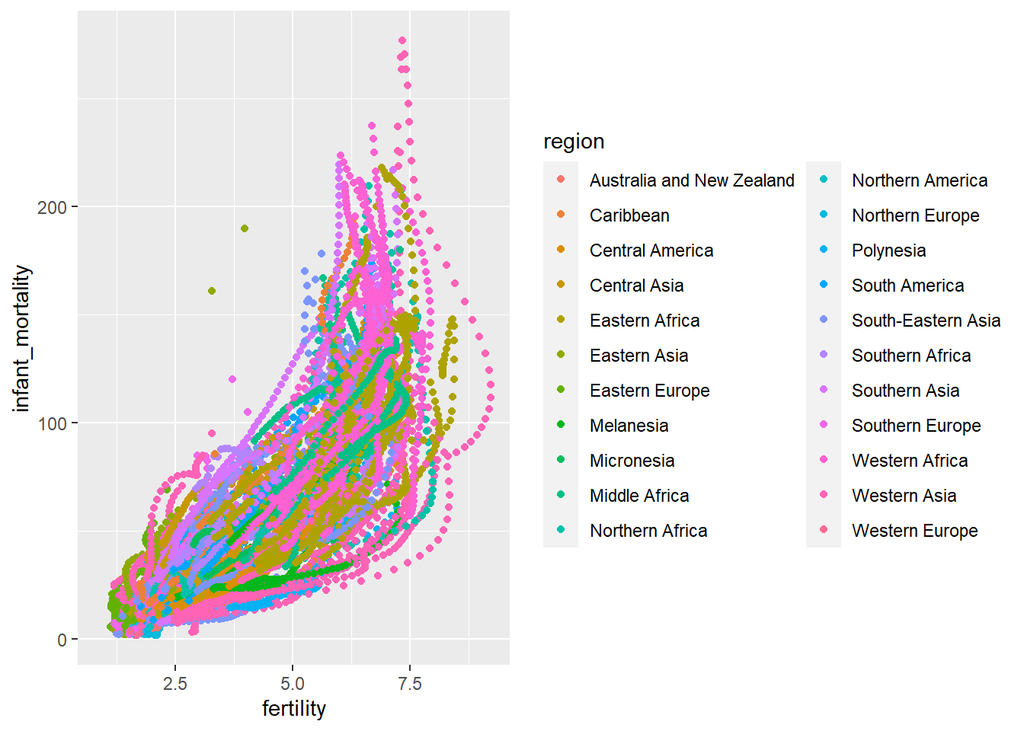

```r
ggplot(gapminder, aes(x=fertility, y=infant_mortality)) +
  geom_point(aes(col=region))
```

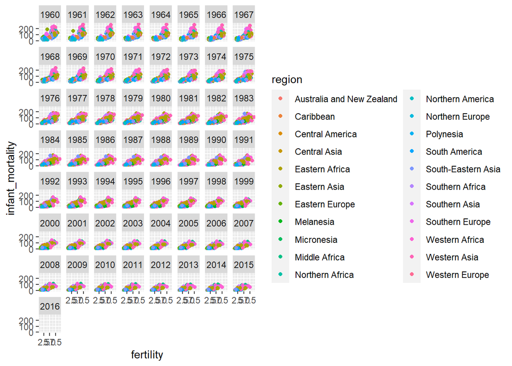

```r
ggplot(gapminder, aes(x=fertility, y=infant_mortality)) +
  geom_point(aes(col=region)) +
  facet_wrap(~year)
```

## Data wrangling with `dplyr`

There are five major `dplyr` functions for wrangling data:

- `select()`: take a subset of the columns (variables/features)
- `filter()`: take a subset of the rows (observations)
- `mutate()`: add or modify existing columns
- `arrange()`: sort the rows
- `summarize()`: aggregate the data across rows (grouping)

## `dplyr` rules for functions

## Piping v. layering

Pipe or layer?

```r
gapminder_short <- gapminder %>% select(gdp, region)
glimpse(gapminder_short)
```

```
## Rows: 10,545
## Columns: 2
## $ gdp    <dbl> NA, 13828152297, NA, NA, 108322326649, NA, NA, 96677859364, ...
## $ region <fct> Southern Europe, Northern Africa, Middle Africa, Caribbean, ...
```

## `filter()`

- `filter()`:

```r
gapminder2000 <- gapminder %>%
  filter(year==2000)
glimpse(gapminder2000)
```

```
## Rows: 185
## Columns: 9
## $ country          <fct> Albania, Algeria, Angola, Antigua and Barbuda, Arg...
## $ year             <int> 2000, 2000, 2000, 2000, 2000, 2000, 2000, 2000, 20...
## $ infant_mortality <dbl> 23.2, 33.9, 128.3, 13.8, 18.0, 26.6, NA, 5.1, 4.6,...
## $ life_expectancy  <dbl> 74.70, 73.30, 52.30, 73.80, 74.20, 71.30, 73.78, 7...
## $ fertility        <dbl> 2.38, 2.51, 6.84, 2.32, 2.48, 1.30, 1.87, 1.76, 1....
## $ population       <dbl> 3121965, 31183658, 15058638, 77648, 37057453, 3076...
## $ gdp              <dbl> 3686649387, 54790058957, 9129180361, 802526701, 28...
## $ continent        <fct> Europe, Africa, Africa, Americas, Americas, Asia, ...
## $ region           <fct> Southern Europe, Northern Africa, Middle Africa, C...
```

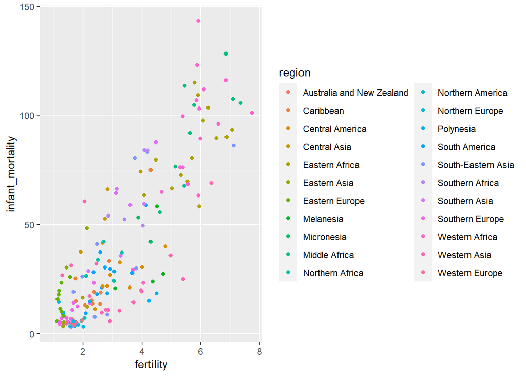

```r
ggplot(gapminder2000, aes(x=fertility, y=infant_mortality)) +
  geom_point(aes(col=region))
```

```r
gapminder %>% filter(year==2000) %>%
  filter(region %in% c('Central Asia',
                       'Eastern Asia',
                       'Polynesia',
                       'South-Eastern Asia',
                       'Southern Asia',
                       'Western Asia')) %>%
  ggplot(aes(x=fertility, y=infant_mortality)) +
  geom_point(aes(col=region))
```

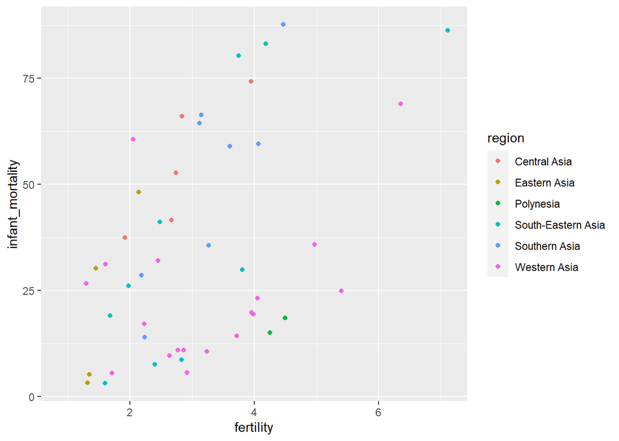

```r
gapminder %>% filter(year==2000) %>%
  filter(region %in% c('Central Asia', 'Eastern Asia',
                       'Polynesia', 'South-Eastern Asia',
                       'Southern Asia', 'Western Asia')) %>%
  ggplot(aes(x=fertility, y=infant_mortality)) +
  geom_point(aes(col=region))
```

## (Smooth) Operators

Explain, in your own words, what these operations do.

- `%>%`:
- `%in%`:
- `==`:

## More Operators

| Operator | Definition |
| --- | --- |
| `<` | less than |
| `<=` | less than or equal to |
| `>` | greater than |
| `>=` | greater than or equal to |
| `==` | exactly equal to |
| `!=` | not equal to |
| `x & y` | `x` AND `y` |
| `x %in% y` | test if `x` is in `y` |

## Fertility and infant mortality in the US

Example: In your notes, modify your plot for another country. Describe how fertility and infant mortality are changing over time.

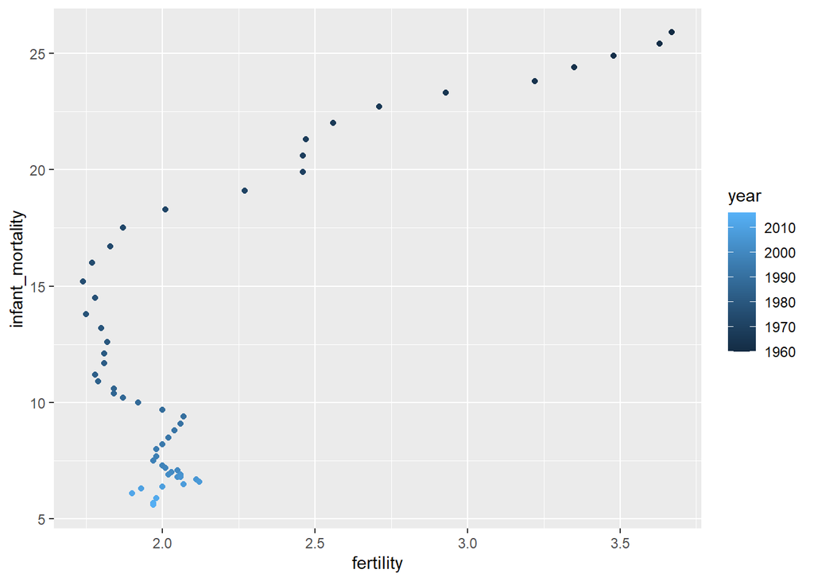

```r
gapminder %>% filter(country=='United States') %>%
  ggplot(aes(x=fertility, y=infant_mortality)) +
  geom_point(aes(col=year))
```

Relationship between fertility and infant mortality over time:

## `mutate()`

- `mutate()` lets us create new variables based on manipulations of the old variables

Example: We’d like to calculate the gross domestic product per capita. Here are the variables in our data - write an expression to do this calculation.

```r
names(gapminder)
```

```
## [1] "country"          "year"             "infant_mortality" "life_expectancy"
## [5] "fertility"        "population"       "gdp"              "continent"
## [9] "region"
```

```r
gapminder <- gapminder %>%
  mutate(GDP_pc = gdp/population)
```

Example: How do we find out which countries have the highest GDP per capita?

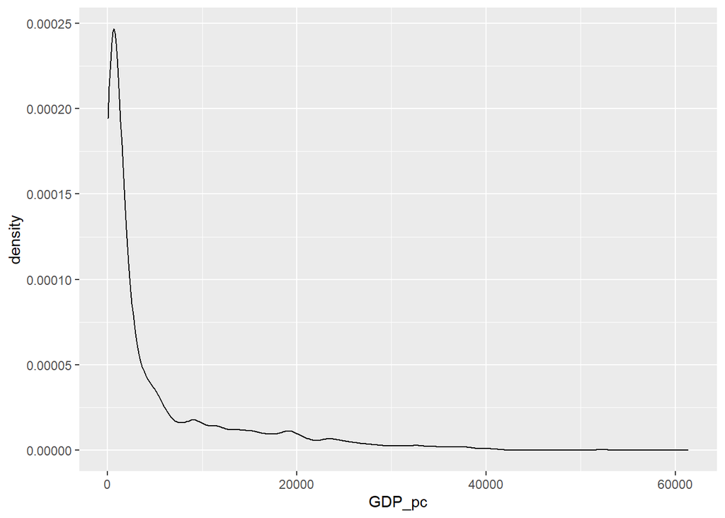

```r
ggplot(gapminder, aes(x=GDP_pc))+geom_density()
```

Example: How do we find out which countries have the highest GDP per capita?

```r
high_GDP <- gapminder %>% filter(GDP_pc>50000)
```

```r
high_GDP
```

```
##                 country year infant_mortality life_expectancy fertility
## 1  United Arab Emirates 1975             45.9           64.30      6.01
## 2  United Arab Emirates 1976             41.9           64.87      5.87
## 3  United Arab Emirates 1977             38.2           65.41      5.74
## 4  United Arab Emirates 1978             34.8           65.93      5.62
## 5  United Arab Emirates 1979             31.7           66.43      5.52
## 6  United Arab Emirates 1980             28.9           66.91      5.42
## 7  United Arab Emirates 1981             26.4           67.36      5.34
## 8  United Arab Emirates 1982             24.2           67.79      5.27
## 9            Luxembourg 2004              3.0           79.50      1.64
## 10           Luxembourg 2005              2.8           80.00      1.63
## 11           Luxembourg 2006              2.6           80.30      1.62
## 12           Luxembourg 2007              2.4           80.60      1.62
## 13           Luxembourg 2008              2.2           81.00      1.63
## 14           Luxembourg 2009              2.0           81.20      1.63
```

[output cut: 19 more lines]

## `arrange()`

```r
GDP_only <- gapminder %>% select(country, year, GDP_pc, continent)
## GDP_only %>% arrange(desc(GDP_pc))
```

```r
GDP_only %>% arrange(continent, desc(GDP_pc))
```

## `summarize()`

If we want to compare summary statistics, we might use `summarize()`.

```r
GDP_only %>% summarize(avg_GDP_pc=mean(GDP_pc),
                       sd_GDP_pc=sd(GDP_pc),
                       min_GDP_pc=min(GDP_pc),
                       max_GDP_pc=max(GDP_pc))
```

```
##   avg_GDP_pc sd_GDP_pc min_GDP_pc max_GDP_pc
## 1         NA        NA         NA         NA
```

```r
GDP_only %>% filter(GDP_pc != "NA") %>%
  summarize(avg_GDP_pc=mean(GDP_pc),
            sd_GDP_pc=sd(GDP_pc),
            min_GDP_pc=min(GDP_pc),
            max_GDP_pc=max(GDP_pc),
            N=n())
```

```
##   avg_GDP_pc sd_GDP_pc min_GDP_pc max_GDP_pc    N
## 1   5583.936  8339.741   54.88963   61340.89 7573
```

```r
GDP_only %>% filter(GDP_pc != "NA") %>%
  group_by(continent) %>%
  summarize(avg_GDP_pc=mean(GDP_pc),
            sd_GDP_pc=sd(GDP_pc),
            min_GDP_pc=min(GDP_pc),
            max_GDP_pc=max(GDP_pc),
            N=n())
```

```
## # A tibble: 5 x 6
##   continent avg_GDP_pc sd_GDP_pc min_GDP_pc max_GDP_pc     N
##   <fct>          <dbl>     <dbl>      <dbl>      <dbl> <int>
## 1 Africa          904.     1289.       54.9      8527.  2270
## 2 Americas       5426.     6315.      370.      38656.  1703
## 3 Asia           5979.     9547.       72.4     61341.  1720
## 4 Europe        12708.    10506.      299.      57017.  1434
## 5 Oceania        5579.     6240.      426.      25439.   446
```

```r
GDP_only %>% filter(GDP_pc != "NA") %>%
  filter(year==2010) %>%
  group_by(continent) %>%
  summarize(avg_GDP_pc=mean(GDP_pc),
            sd_GDP_pc=sd(GDP_pc),
            min_GDP_pc=min(GDP_pc),
            max_GDP_pc=max(GDP_pc),
            N=n())
```

```
## # A tibble: 5 x 6
##   continent avg_GDP_pc sd_GDP_pc min_GDP_pc max_GDP_pc     N
##   <fct>          <dbl>     <dbl>      <dbl>      <dbl> <int>
## 1 Africa         1303.     1886.       106.      8205.    49
## 2 Americas       6797.     7745.       370.     37266.    33
## 3 Asia           8163.    11381.       253.     40013.    45
## 4 Europe        15214.    13487.       520.     52210.    39
## 5 Oceania        5281.     8234.       741.     25405.    10
```

Reflection Questions:

1. With 1 being too slow and 5 being too fast, how was the speed of the video?
2. With 1 being too basic and 5 being too advanced, how was the level of the video?
3. Are there any topics you specifically want to address during the class meeting?
4. Any additonal thoughts/comments on the notes: